# Part I - (Dataset Exploration Title)

# by (Oluwatosin K.)

## Introduction

> This data set contains 113,937 loans with 81 variables on each loan, including loan amount, interest rate, current loan status, borrower income, and many others. We would be exploring this dataset to find useful insights on borrowers and to observe if there are any notable patterns.

## Preliminary Wrangling

```python
# import all packages and set plots to be embedded inline
import numpy as np
import pandas as pd
import matplotlib.pyplot as plt
import seaborn as sns
import calendar
import warnings
warnings.filterwarnings('ignore')

%matplotlib inline
```

```python
df_original = pd.read_csv('prosperLoanData.csv')
```

### Getting more info about the data: shape, missing data e.t.c

```python
df_original.shape
```

```
(113937, 81)
```

```python
df_original.sample(5)
```

|  | ListingKey | ListingNumber | ListingCreationDate | CreditGrade | Term | LoanStatus | ClosedDate | BorrowerAPR | BorrowerRate | LenderYield | ... | LP_ServiceFees | LP_CollectionFees | LP_GrossPrincipalLoss | LP_NetPrincipalLoss | LP_NonPrincipalRecoverypayments | PercentFunded | Recommendations | InvestmentFromFriendsCount | InvestmentFromFriendsAmount | Investors |
| --- | --- | --- | --- | --- | --- | --- | --- | --- | --- | --- | --- | --- | --- | --- | --- | --- | --- | --- | --- | --- | --- |
| 7863 | 9B8B3581244509781C64223 | 799973 | 2013-06-06 20:52:26.337000000 | NaN | 36 | Current | NaN | 0.29537 | 0.2566 | 0.2466 | ... | -25.06 | 0.0 | 0.0 | 0.0 | 0.0 | 1.0 | 0 | 0 | 0.0 | 20 |
| 112040 | F0813593104873092646E8F | 963043 | 2013-10-29 06:28:03.900000000 | NaN | 36 | Current | NaN | 0.15833 | 0.1299 | 0.1199 | ... | -31.76 | 0.0 | 0.0 | 0.0 | 0.0 | 1.0 | 0 | 0 | 0.0 | 1 |
| 34647 | 73A6359159149187636E094 | 966089 | 2013-10-23 09:35:29.897000000 | NaN | 36 | Current | NaN | 0.33215 | 0.2925 | 0.2825 | ... | -13.12 | 0.0 | 0.0 | 0.0 | 0.0 | 1.0 | 0 | 0 | 0.0 | 1 |
| 13952 | 9AB936028013106466AF3A5 | 1210758 | 2014-02-15 14:05:38.450000000 | NaN | 36 | Current | NaN | 0.31975 | 0.2800 | 0.2700 | ... | 0.00 | 0.0 | 0.0 | 0.0 | 0.0 | 1.0 | 0 | 0 | 0.0 | 1 |
| 102956 | 91A3358197687469938415D | 824803 | 2013-06-30 13:39:41.053000000 | NaN | 36 | Past Due (1-15 days) | NaN | 0.20053 | 0.1639 | 0.1539 | ... | -61.31 | -180.3 | 0.0 | 0.0 | 0.0 | 1.0 | 0 | 0 | 0.0 | 140 |

5 rows × 81 columns

### QUESTIONS

How many Borrowers have a verifiable source of income?

What's the average payback period?

What's the Income range across various Occupations?

What State has the highest no of debtors?

Whats the most popular reason take a loan?

What's the average payback period?

How does loan amount differ across income ranges?

What factors affect a loan’s outcome status?

```python
df_original.info()
```

```
<class 'pandas.core.frame.DataFrame'>
RangeIndex: 113937 entries, 0 to 113936
Data columns (total 81 columns):
 #   Column                               Non-Null Count   Dtype
---  ------                               --------------   -----
 0   ListingKey                           113937 non-null  object
 1   ListingNumber                        113937 non-null  int64
 2   ListingCreationDate                  113937 non-null  object
 3   CreditGrade                          28953 non-null   object
 4   Term                                 113937 non-null  int64
 5   LoanStatus                           113937 non-null  object
 6   ClosedDate                           55089 non-null   object
 7   BorrowerAPR                          113912 non-null  float64
 8   BorrowerRate                         113937 non-null  float64
 9   LenderYield                          113937 non-null  float64
```

[output cut: 73 more lines]

#### many of the colums have missing values, so I'll be selecting some of the columns i need also looking out for columns with complete data.

```python
df_original.columns.to_list
```

```
<bound method IndexOpsMixin.tolist of Index(['ListingKey', 'ListingNumber', 'ListingCreationDate', 'CreditGrade',
       'Term', 'LoanStatus', 'ClosedDate', 'BorrowerAPR', 'BorrowerRate',
       'LenderYield', 'EstimatedEffectiveYield', 'EstimatedLoss',
       'EstimatedReturn', 'ProsperRating (numeric)', 'ProsperRating (Alpha)',
       'ProsperScore', 'ListingCategory (numeric)', 'BorrowerState',
       'Occupation', 'EmploymentStatus', 'EmploymentStatusDuration',
       'IsBorrowerHomeowner', 'CurrentlyInGroup', 'GroupKey',
       'DateCreditPulled', 'CreditScoreRangeLower', 'CreditScoreRangeUpper',
       'FirstRecordedCreditLine', 'CurrentCreditLines', 'OpenCreditLines',
       'TotalCreditLinespast7years', 'OpenRevolvingAccounts',
       'OpenRevolvingMonthlyPayment', 'InquiriesLast6Months', 'TotalInquiries',
       'CurrentDelinquencies', 'AmountDelinquent', 'DelinquenciesLast7Years',
       'PublicRecordsLast10Years', 'PublicRecordsLast12Months',
       'RevolvingCreditBalance', 'BankcardUtilization',
       'AvailableBankcardCredit', 'TotalTrades',
       'TradesNeverDelinquent (percentage)', 'TradesOpenedLast6Months',
       'DebtToIncomeRatio', 'IncomeRange', 'IncomeVerifiable',
       'StatedMonthlyIncome', 'LoanKey', 'TotalProsperLoans',
       'TotalProsperPaymentsBilled', 'OnTimeProsperPayments',
       'ProsperPaymentsLessThanOneMonthLate',
       'ProsperPaymentsOneMonthPlusLate', 'ProsperPrincipalBorrowed',
       'ProsperPrincipalOutstanding', 'ScorexChangeAtTimeOfListing',
       'LoanCurrentDaysDelinquent', 'LoanFirstDefaultedCycleNumber',
       'LoanMonthsSinceOrigination', 'LoanNumber', 'LoanOriginalAmount',
       'LoanOriginationDate', 'LoanOriginationQuarter', 'MemberKey',
       'MonthlyLoanPayment', 'LP_CustomerPayments',
       'LP_CustomerPrincipalPayments', 'LP_InterestandFees', 'LP_ServiceFees',
       'LP_CollectionFees', 'LP_GrossPrincipalLoss', 'LP_NetPrincipalLoss',
       'LP_NonPrincipalRecoverypayments', 'PercentFunded', 'Recommendations',
       'InvestmentFromFriendsCount', 'InvestmentFromFriendsAmount',
       'Investors'],
      dtype='object')>
```

```python
# Creating a new dataframe df_need for the columns i will be using.

need_columns=['MemberKey','LoanOriginationDate','LoanOriginalAmount','Term','MonthlyLoanPayment', 'BorrowerRate', 'LoanStatus','ListingCategory (numeric)', 'BorrowerState',
       'Occupation', 'EmploymentStatus', 'EmploymentStatusDuration',
       'IsBorrowerHomeowner','IncomeRange', 'IncomeVerifiable',
       'StatedMonthlyIncome','AvailableBankcardCredit','Investors']
```

```python
df_loan= df_original[need_columns]
df_loan.shape
```

```
(113937, 18)
```

#### I would like to convert the numeric listing category into text.

```python
ListingCategory1= {0:'Not Available', 1:'Debt Consolidation', 2:'Home Improvement', 3:'Business', 4:'Personal Loan', 5:'Student Use', 6:'Auto', 7:'Other', 8:'Baby or Adoption', 9:'Boat', 10:'Cosmetic Procedure', 11:'Engagement Ring', 12:'Green Loans', 13:'Household Expenses', 14:'Large Purchases', 15:'Medical/Dental', 16:'Motorcycle', 17:'RV', 18:'Taxes', 19:'Vacation', 20:'Wedding Loans'}
```

```python
df_loan['ListingCategory'] = df_loan['ListingCategory (numeric)']
df_loan['ListingCategory'].replace(ListingCategory1, inplace=True)
df_loan.head()
```

|  | MemberKey | LoanOriginationDate | LoanOriginalAmount | Term | MonthlyLoanPayment | BorrowerRate | LoanStatus | ListingCategory (numeric) | BorrowerState | Occupation | EmploymentStatus | EmploymentStatusDuration | IsBorrowerHomeowner | IncomeRange | IncomeVerifiable | StatedMonthlyIncome | AvailableBankcardCredit | Investors | ListingCategory |
| --- | --- | --- | --- | --- | --- | --- | --- | --- | --- | --- | --- | --- | --- | --- | --- | --- | --- | --- | --- |
| 0 | 1F3E3376408759268057EDA | 2007-09-12 00:00:00 | 9425 | 36 | 330.43 | 0.1580 | Completed | 0 | CO | Other | Self-employed | 2.0 | True | $25,000-49,999 | True | 3083.333333 | 1500.0 | 258 | Not Available |
| 1 | 1D13370546739025387B2F4 | 2014-03-03 00:00:00 | 10000 | 36 | 318.93 | 0.0920 | Current | 2 | CO | Professional | Employed | 44.0 | False | $50,000-74,999 | True | 6125.000000 | 10266.0 | 1 | Home Improvement |
| 2 | 5F7033715035555618FA612 | 2007-01-17 00:00:00 | 3001 | 36 | 123.32 | 0.2750 | Completed | 0 | GA | Other | Not available | NaN | False | Not displayed | True | 2083.333333 | NaN | 41 | Not Available |
| 3 | 9ADE356069835475068C6D2 | 2012-11-01 00:00:00 | 10000 | 36 | 321.45 | 0.0974 | Current | 16 | GA | Skilled Labor | Employed | 113.0 | True | $25,000-49,999 | True | 2875.000000 | 30754.0 | 158 | Motorcycle |
| 4 | 36CE356043264555721F06C | 2013-09-20 00:00:00 | 15000 | 36 | 563.97 | 0.2085 | Current | 2 | MN | Executive | Employed | 44.0 | True | $100,000+ | True | 9583.333333 | 695.0 | 20 | Home Improvement |

## Univariate Visualizations

### 1 How many people had verifiable income?

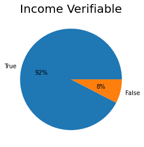

```python
df_loan['IncomeVerifiable'].value_counts().plot(kind ='pie', autopct='%.0f%%', figsize=(6,4))
plt.title('Income Verifiable', fontsize=20)
plt.ylabel('',fontsize=20);
```

#### Observation 1: Majority of the population, 92% to be precise have verifiable income.

### 2 Employment Distribution of Dataset

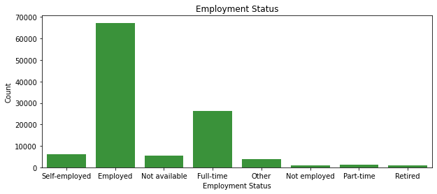

```python
plt.figure(figsize= (10,4))
base_color=sns.color_palette()[2]
sns.countplot(data=df_loan, x='EmploymentStatus', color =base_color)
plt.title('Employment Status',)
plt.xlabel('Employment Status')
plt.ylabel('Count');
```

#### Observation 2: The categories for employment status are confusing, full time and part time look like they should be subsectors of employed, not standalone sectors

### 3. What are the occupations of those taking loans?

```
67
```

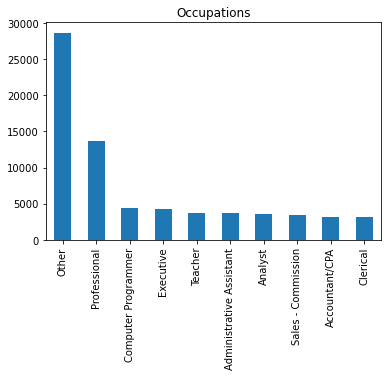

```python
df_loan['Occupation'].value_counts().head(10).plot(kind ='bar')
plt.title('Occupations')
df_loan['Occupation'].nunique()
```

#### Observation 3: There are 67 unique professions represented within the borrower Data. The top 10 occupations have been represented in the chart above.

### 4 What are the common reasons behind these loans?

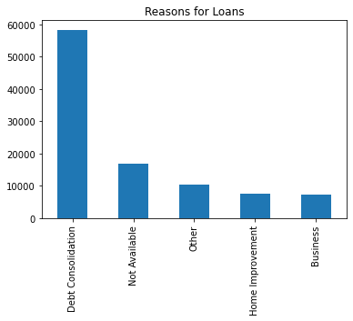

```python
df_loan['ListingCategory'].value_counts().head(5).plot(kind ='bar')
plt.title('Reasons for Loans');
```

#### Observation 4: Debt consolidation happens to be by far the most common reason behind the loans.

### 5. Income range distribution

```python
df_loan.IncomeRange.unique().tolist()
```

```
['$25,000-49,999',
 '$50,000-74,999',
 'Not displayed',
 '$100,000+',
 '$75,000-99,999',
 '$1-24,999',
 'Not employed',
 '$0']
```

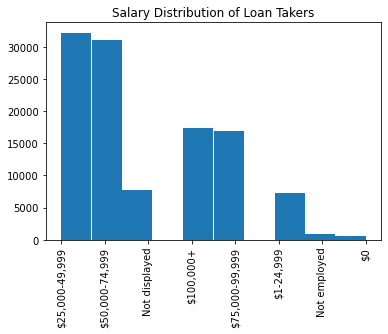

```python
plt.hist(data=df_loan, x='IncomeRange', rwidth=0.99)
plt.xticks(rotation=90);
plt.title('Salary Distribution of Loan Takers',);
```

#### Observation 5: Majority of borrowers earn between 25 and 75 thousand dollars.

### 6 How many Borrowers own a Home?

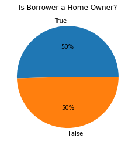

```python
# How many people had verifiable income?
df_loan['IsBorrowerHomeowner'].value_counts().plot(kind ='pie', autopct='%.0f%%', figsize=(6,4))
plt.title('Is Borrower a Home Owner?',)
plt.ylabel('');
```

#### Observation 6: Half of the Population are Home Owners and half are not.

### 7. Distribution of Payback Period

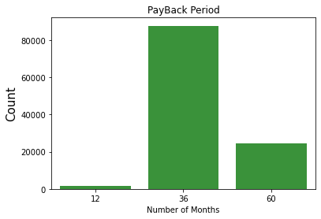

```python
plt.figure()
base_color=sns.color_palette()[2]
sns.countplot(data=df_loan, x='Term', color=base_color)
plt.title('PayBack Period', )
plt.xlabel('Number of Months',)
plt.ylabel('Count',fontsize=15);
```

#### Observation 7: Most Borrowers find it comfortable to pay within 3 years i.e 36 years.

### 8. What state has the highest number of Borrowers?

```python
df_loan['BorrowerState'].nunique()
```

```
51
```

```
51
```

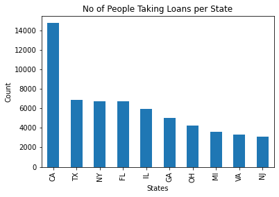

```python
plt.figure()
df_loan['BorrowerState'].value_counts().head(10).plot(kind ='bar')
plt.title('No of People Taking Loans per State',)
plt.xlabel('States',)
plt.ylabel('Count',);
df_loan['BorrowerState'].nunique()
```

#### Observation7: The state with the Highest no of loans is California, followed by Texas,NewYork and Florida which all have values less than half that of California.

### Summary Statistics for some of the columns

```python
df_loan[['LoanOriginalAmount','MonthlyLoanPayment', 'BorrowerRate', 'StatedMonthlyIncome', 'Term','EmploymentStatusDuration']].describe()
```

|  | LoanOriginalAmount | MonthlyLoanPayment | BorrowerRate | StatedMonthlyIncome | Term | EmploymentStatusDuration |
| --- | --- | --- | --- | --- | --- | --- |
| count | 113937.00000 | 113937.000000 | 113937.000000 | 1.139370e+05 | 113937.000000 | 106312.000000 |
| mean | 8337.01385 | 272.475783 | 0.192764 | 5.608026e+03 | 40.830248 | 96.071582 |
| std | 6245.80058 | 192.697812 | 0.074818 | 7.478497e+03 | 10.436212 | 94.480605 |
| min | 1000.00000 | 0.000000 | 0.000000 | 0.000000e+00 | 12.000000 | 0.000000 |
| 25% | 4000.00000 | 131.620000 | 0.134000 | 3.200333e+03 | 36.000000 | 26.000000 |
| 50% | 6500.00000 | 217.740000 | 0.184000 | 4.666667e+03 | 36.000000 | 67.000000 |
| 75% | 12000.00000 | 371.580000 | 0.250000 | 6.825000e+03 | 36.000000 | 137.000000 |
| max | 35000.00000 | 2251.510000 | 0.497500 | 1.750003e+06 | 60.000000 | 755.000000 |

```python
# are there people with more than one current loan i.e LoanStatus=Current
df_loan.query('LoanStatus=="Current"').MemberKey.duplicated().value_counts(sort=False).to_frame()
```

|  | MemberKey |
| --- | --- |
| False | 51814 |
| True | 4762 |

#### Observation: There are members with more than one loan.

## Bivariate Visualizations

```python
df_loan.columns
```

```
Index(['MemberKey', 'LoanOriginationDate', 'LoanOriginalAmount', 'Term',
       'MonthlyLoanPayment', 'BorrowerRate', 'LoanStatus',
       'ListingCategory (numeric)', 'BorrowerState', 'Occupation',
       'EmploymentStatus', 'EmploymentStatusDuration', 'IsBorrowerHomeowner',
       'IncomeRange', 'IncomeVerifiable', 'StatedMonthlyIncome',
       'AvailableBankcardCredit', 'Investors', 'ListingCategory'],
      dtype='object')
```

### 9 Loan Status Distribution VS Listing Category

```python
def loanstatuts (filter_var,title) :
    df_loan.query(filter_var).LoanStatus.value_counts(sort=True).plot(kind='bar')
    plt.title(title, fontsize=20)
    plt.xticks(fontsize=12)
    plt.yticks(fontsize=12);
```

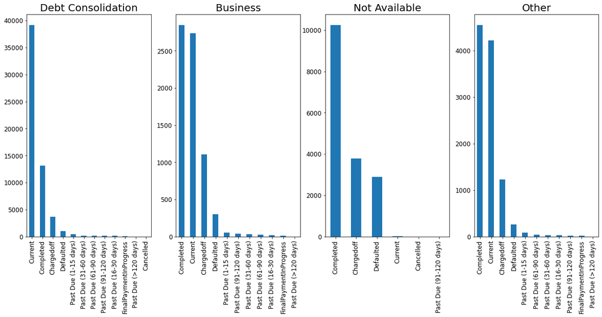

```python
# How many of the people who borrow loans for Debt Consolidation actually payback
plt.figure(figsize=[20,8])
#plt.subplots(3,2)
plt.subplot(1,4,1).figsize=[5,3]
loanstatuts('ListingCategory=="Debt Consolidation"','Debt Consolidation')

plt.subplot(1,4,2)
loanstatuts('ListingCategory=="Business"','Business')

plt.subplot(1,4,3)
loanstatuts('ListingCategory=="Not Available"','Not Available')


plt.subplot(1,4,4)
loanstatuts('ListingCategory=="Other"','Other')
```

#### Observation 9: Those who Borrow loans for Debt consolidation reasons have the highest current Loan status. Those who gave 'Not availa ble reason for their loans had a much higher default rate than others.

### 10 income distribution of people in Different Listing category

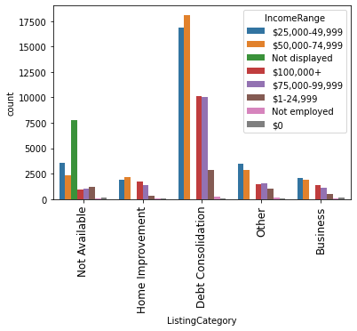

```python
# What's the income distribution of people with consolidated loans.
filter_list = df_loan.ListingCategory.value_counts().head(5).index.to_list()
plt.figure()
sns.countplot(data=df_loan.query('ListingCategory==@filter_list'), x='ListingCategory', hue='IncomeRange')
plt.xticks(fontsize=12, rotation=90);
```

### 11 Percentage of home owners for each occupation

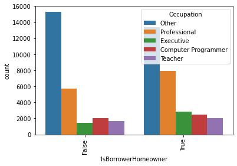

```python
filter_list = df_loan.Occupation.value_counts().head(5).index.to_list()
plt.figure()
sns.countplot(data=df_loan.query('Occupation==@filter_list'), x='IsBorrowerHomeowner', hue='Occupation')
plt.xticks(rotation=90);
```

### 12 Monthly income against Original Loan Amount

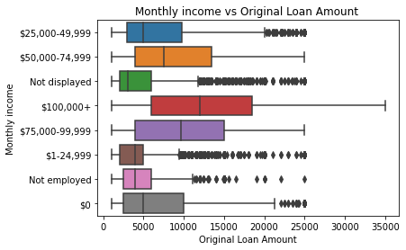

```python
plt.figure()
sns.boxplot(x=df_loan['LoanOriginalAmount'], y=df_loan['IncomeRange'])
plt.title("Monthly income vs Original Loan Amount ", )
plt.xlabel('Original Loan Amount',)
plt.ylabel('Monthly income',)
plt.xticks()
plt.yticks();
plt.show()
```

#### Observation 12: Here we see that the median loan amount for each income range increases with income range.

### 13 Original Loan Amount against Term

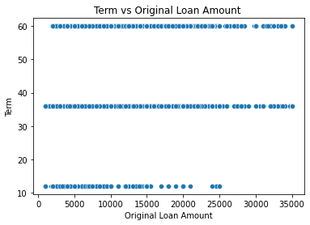

```python
plt.figure()
sns.scatterplot(x=df_loan['LoanOriginalAmount'], y=df_loan['Term'])
plt.title("Term vs Original Loan Amount ",)
plt.xlabel('Original Loan Amount',)
plt.ylabel('Term',)
plt.xticks()
plt.yticks();
plt.show()
```

#### Observation 13: Very few people pay within twelve months i.e One year.

### 14 Borrower State against Employment status

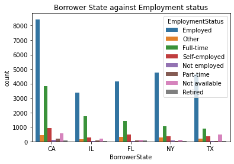

```python
filter_list = df_loan.BorrowerState.value_counts().head(5).index.to_list()
plt.title('Borrower State against Employment status')
sns.countplot(data=df_loan.query('BorrowerState==@filter_list'),x='BorrowerState',hue='EmploymentStatus');
```

### 15 borrower state vs monthly income

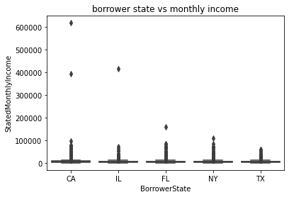

```python
plt.title('borrower state vs monthly income')
sns.boxplot(data=df_loan.query('BorrowerState==@filter_list'),x='BorrowerState',y='StatedMonthlyIncome');
```

#### Observation 15: California has the highest monthly income as seen by the outlier.

## *Multivariate Visualizations*

### 16 Correlations between features

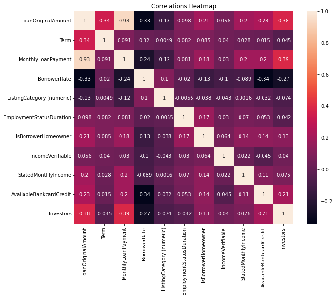

```python
plt.figure(figsize=(10,8))
plt.title('Correlations Heatmap')
sns.heatmap(df_loan.corr(),annot=True);
```

#### Observation 15: The loan original amount has a strong correllation to the Monthly Payment amount.

#### Conclusions

Many Calofornians live off loans trying to pay other debts, inspite of being one of the states with higher income ranges.

I observed a higher current Loan status for people within the debt consolidation category.

Only a few people pay within a year, majority of the Borrowers find it comfortable to payback within a 3 year/ 36-month payback period.

I observed that the median Original Loan amount Increases with Increase in income range of members.

Fewer higher earners of 75,000 dollars and above took loans compared to those below the median earning range.